# GDP per capita and development aid

Haraldur Bjarni Davíðsson

10/24/2019

# Inngangur

## Innlestur gagna

Gögnin eru lesin inn og í kjölfarið eru þau hreinsuð. Ýmsir dálkar, ásamt fyrstu fjórum línunum eru teknar í burtu svo gögnin verði læsilegri og auðveldari í meðförum. Fyrir neðan kóðann eru fyrstu 9 dálkar og 6 línur í gdp gagnasettinu.

```r
gdp<-read.csv(file="gdp2/API_NY.GDP.PCAP.CD_DS2_en_csv_v2_511373.csv",sep=",",skip=4,header=T)
devaid<-read.csv(file="devhelp/API_DT.ODA.ODAT.CD_DS2_en_csv_v2_385593.csv",sep=",",skip=4,header=T)
colnames(gdp)<-gsub('X',"",colnames(gdp),fixed=TRUE)
colnames (devaid)<-gsub('X',"",colnames(devaid),fixed=TRUE)

head(gdp %>% select(1:9))
```

```
##   Country.Name Country.Code               Indicator.Name Indicator.Code
## 1        Aruba          ABW GDP per capita (current US$) NY.GDP.PCAP.CD
## 2  Afghanistan          AFG GDP per capita (current US$) NY.GDP.PCAP.CD
## 3       Angola          AGO GDP per capita (current US$) NY.GDP.PCAP.CD
## 4      Albania          ALB GDP per capita (current US$) NY.GDP.PCAP.CD
## 5      Andorra          AND GDP per capita (current US$) NY.GDP.PCAP.CD
## 6   Arab World          ARB GDP per capita (current US$) NY.GDP.PCAP.CD
##       1960     1961     1962     1963     1964
## 1       NA       NA       NA       NA       NA
## 2 59.77319 59.86087 58.45801 78.70639 82.09523
## 3       NA       NA       NA       NA       NA
## 4       NA       NA       NA       NA       NA
## 5       NA       NA       NA       NA       NA
## 6       NA       NA       NA       NA       NA
```

## Gagnaummyndun

Gögnunum er breytt, tvær nýjar töflur eru lesnar inn fyrir sitt hvora töfluna, þ.e. gdp og devaid, með því að nota melt skipunina. Fyrir töfluna sem geymir verga landsframleiðslu eru töflurnar gdp_by_country_name og gdp_by_country_code búnar til. Báðar töflurnar innihalda þrjá dálka, bæði hafa þau Year, sem geymir árið, GDP_per_capita sem geymir verga landsframleiðsluna m.v. höfðatölu. Auk þess inniheldur önnur þeirra Country_name sem geymir nafn landsins, en hin Country_id sem geymir auðkennisbókstafi landsins. Ástæðan fyrir þeessari skiptingu er vegna þess að þegar Country.name er borið saman við nafn á sama landi í öðru landagagnasetti gætu nöfnin verið á mismunandi formi. T.d. er country name fyrir Rússland “Russian Federation” en í einhverju öðru gæti það verið “Russia”. Country id-ið myndi hins vegar mjög sennilega vera það sama. Sama skiptingin var síðan gerð fyir devaid töfluna nema að Development_help dálkurinn kom í staðinn fyrir GDP_per_capita. Eftir þessa síu eru gögnin komin á betra form fyrir frekari úrvinnslu gagnanna. Fyrir neðan kóðann eru allir dálkar og 6 fyrstu línur í öllum gagnasettunum.

```r
gdp_by_country_code<-gdp
gdp_by_country_name <- gdp[ -c(2:4,64) ]
gdp_by_country_code <- gdp[ -c(1,3,4,34) ]
gdp_by_country_name<-melt(gdp_by_country_name,"Country.Name")
gdp_by_country_code<-melt(gdp_by_country_code,"Country.Code")
colnames(gdp_by_country_name)<-c("Country_name", "Year", "GDP_per_capita")
gdp_by_country_name$Year<-as.integer(as.character(gdp_by_country_name$Year))
gdp_by_country_name <- na.omit(gdp_by_country_name)
colnames(gdp_by_country_code)<-c("Country_id", "Year", "GDP_per_capita")
gdp_by_country_code$Year<-as.integer(as.character(gdp_by_country_code$Year))
gdp_by_country_code <- na.omit(gdp_by_country_code)

devaid_by_country_code<-devaid
devaid_by_country_name <- devaid[ -c(2:4,64) ]
devaid_by_country_code <- devaid_by_country_code[ -c(1,3,4,34) ]
devaid_by_country_name<-melt(devaid_by_country_name,"Country.Name")
devaid_by_country_code<-melt(devaid_by_country_code,"Country.Code")
colnames(devaid_by_country_name)<-c("Country_name", "Year", "Development_aid")
devaid_by_country_name$Year<-as.integer(as.character(devaid_by_country_name$Year))
devaid_by_country_name <- na.omit(devaid_by_country_name)
colnames(devaid_by_country_code)<-c("Country_id", "Year", "Development_aid")
devaid_by_country_code$Year<-as.integer(as.character(devaid_by_country_code$Year))
devaid_by_country_code <- na.omit(devaid_by_country_code)

head(gdp_by_country_name)
```

```
##    Country_name Year GDP_per_capita
## 2   Afghanistan 1960       59.77319
## 12    Australia 1960     1807.78571
## 13      Austria 1960      935.46043
## 15      Burundi 1960       70.05173
## 16      Belgium 1960     1273.69166
## 17        Benin 1960       93.02251
```

```r
head(gdp_by_country_code)
```

```
##    Country_id Year GDP_per_capita
## 2         AFG 1960       59.77319
## 12        AUS 1960     1807.78571
## 13        AUT 1960      935.46043
## 15        BDI 1960       70.05173
## 16        BEL 1960     1273.69166
## 17        BEN 1960       93.02251
```

```r
head(devaid_by_country_name)
```

```
##            Country_name Year Development_aid
## 2           Afghanistan 1960        17180000
## 3                Angola 1960          -50000
## 6            Arab World 1960       881990000
## 7  United Arab Emirates 1960          410000
## 8             Argentina 1960        28580000
## 15              Burundi 1960         7530000
```

```r
head(devaid_by_country_code)
```

```
##    Country_id Year Development_aid
## 2         AFG 1960        17180000
## 3         AGO 1960          -50000
## 6         ARB 1960       881990000
## 7         ARE 1960          410000
## 8         ARG 1960        28580000
## 15        BDI 1960         7530000
```

## Myndræn framsetning á vergri landsframleiðslu

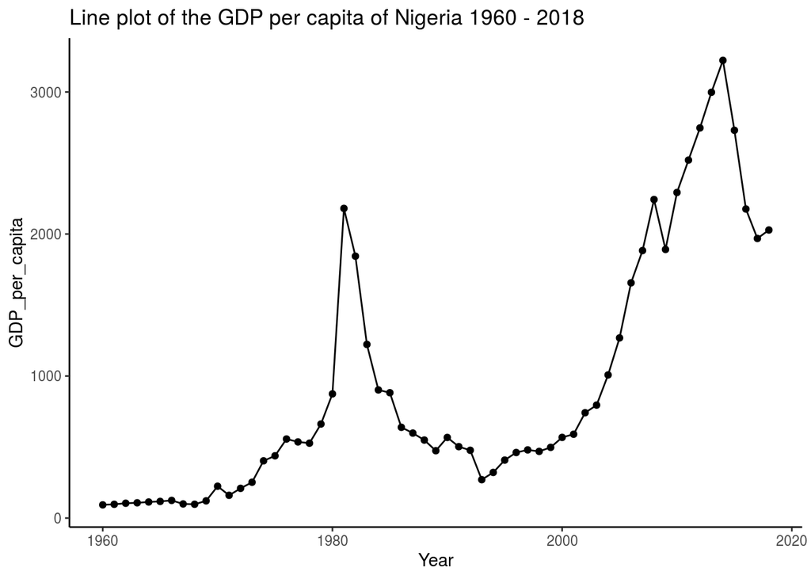

```r
lineplot_country_gdp_by_years<- function(yearFrom,yearTo,country) {
  dat<-gdp_by_country_name%>%filter(Country_name==country & Year>=yearFrom & Year<=yearTo)
  chr = sprintf("Line plot of the GDP per capita of %s %d - %d",country,yearFrom,yearTo)
  ggplot(data = dat, aes(x = Year, y = GDP_per_capita))+geom_point()+geom_line()+ggtitle(chr)+theme(plot.title = element_text(lineheight=.8, face="bold"))+theme_classic()
}

barplot_country_gdp_by_years<- function(yearFrom,yearTo,country) {
  dat<-gdp_by_country_name%>%filter(Country_name==country & Year>=yearFrom & Year<=yearTo)
  chr = sprintf("Bar plot of the GDP per capita of %s %d - %d",country,yearFrom,yearTo)
  ggplot(data = dat, aes(x = Year, y = GDP_per_capita, fill=GDP_per_capita))+geom_bar(stat = "identity")+ggtitle(chr)+theme(plot.title = element_text(lineheight=.8, face="bold"))+theme_classic()
}

lineplot_countries_gdp_by_years<- function(yearFrom,yearTo,conts) {
  dat<-gdp_by_country_name%>%filter(Year>=yearFrom & Year<=yearTo & Country_name %in% conts)
  chr = sprintf("Line plot of the GDP per capita of selected countries %d - %d",yearFrom,yearTo)
  ggplot(data = dat, aes(x =Year, y = GDP_per_capita, color=Country_name))+geom_point()+geom_line()+ggtitle(chr)+
  theme(plot.title = element_text(lineheight=.8, face="bold"))+theme_classic()
}

barplot_countries_gdp_by_year<- function(year,conts) {
  dat<-gdp_by_country_name%>%filter(year==Year & Country_name %in% conts)
   chr = sprintf("Bar plot of the GDP per capita of selected countries in %d",year)
   ggplot(data = dat, aes(x = Country_name, y = GDP_per_capita, fill=Country_name))+geom_bar(stat = "identity")+
   theme(plot.title = element_text(lineheight=.8, face="bold"), axis.text.x = element_text(angle = 90, hjust = 1))+ggtitle(chr)+theme_classic()
}
worldplot_by_year<- function(year) {
  world <- ne_countries(scale = "medium", returnclass = "sf")
  dat<-gdp_by_country_code%>%filter(Year == year)
  newdat<-merge(x=world,y=dat,by.x="brk_a3",by.y="Country_id",all.x=TRUE)
  chr = sprintf("World view of the GDP per capita %d",year)
  ggplot(newdat, main = chr)+
  geom_sf(data = newdat, aes(fill = GDP_per_capita,)) +
  scale_fill_viridis_c(option = "inferno", trans = "log2")+
  theme(plot.title = element_text(lineheight=.8, face="bold"))+ggtitle(chr)+theme_bw()
}

continentplot_by_year <- function(cont, year) {
  world <- ne_countries(scale = "medium", returnclass = "sf")
  world <- filter(world,continent == cont)
  dat<-gdp_by_country_code%>%filter(Year == year)
  newdat<-merge(x=world,y=dat,by.x="brk_a3",by.y="Country_id",all.x=TRUE)
  chr = sprintf("The GDP per capita of %s %d",cont,year)
  ggplot(newdat, main = chr)+
  geom_sf(data = newdat, aes(fill = GDP_per_capita,)) +
  scale_fill_viridis_c(option = "inferno", trans = "log2")+
  theme(plot.title = element_text(lineheight=.8, face="bold"))+ggtitle(chr)+theme_bw()
}

lineplot_country_gdp_by_years(1960,2018,"Nigeria")
```

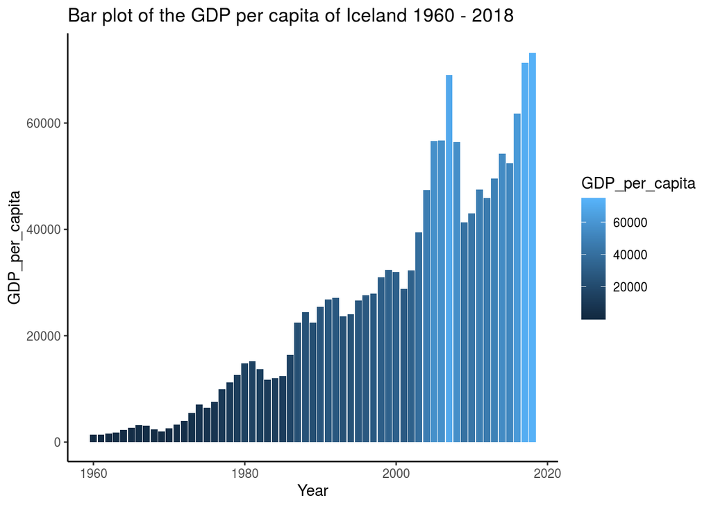

```r
barplot_country_gdp_by_years(1960,2018,"Iceland")
```

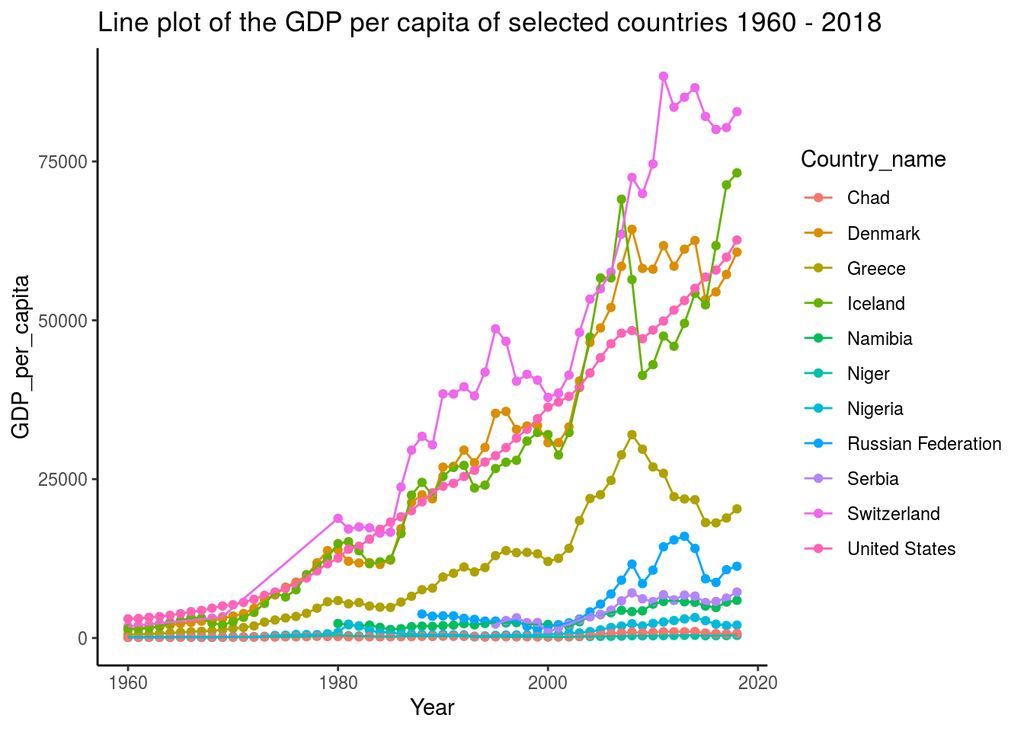

```r
lineplot_countries_gdp_by_years(1960,2018,conts=c("Namibia", "Chad", "Nigeria","Niger", "United States","Serbia","Russian Federation","Iceland","Denmark","Greece","Switzerland"))
```

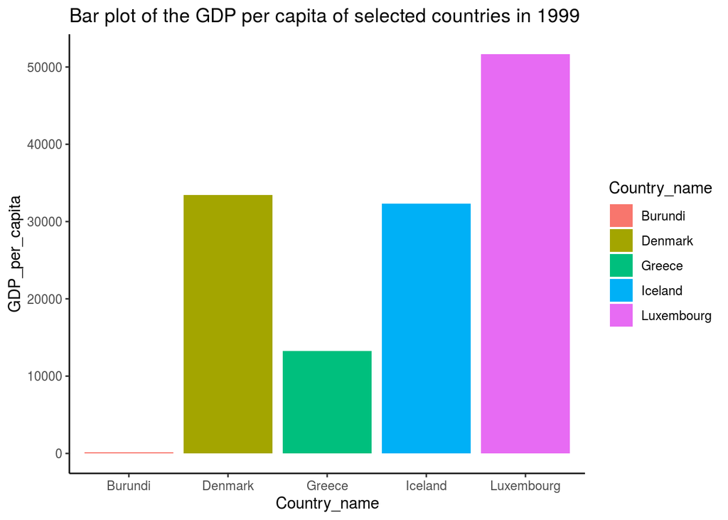

```r
barplot_countries_gdp_by_year(1999,conts=c("Iceland","Denmark","Greece","Luxembourg","Burundi"))
```

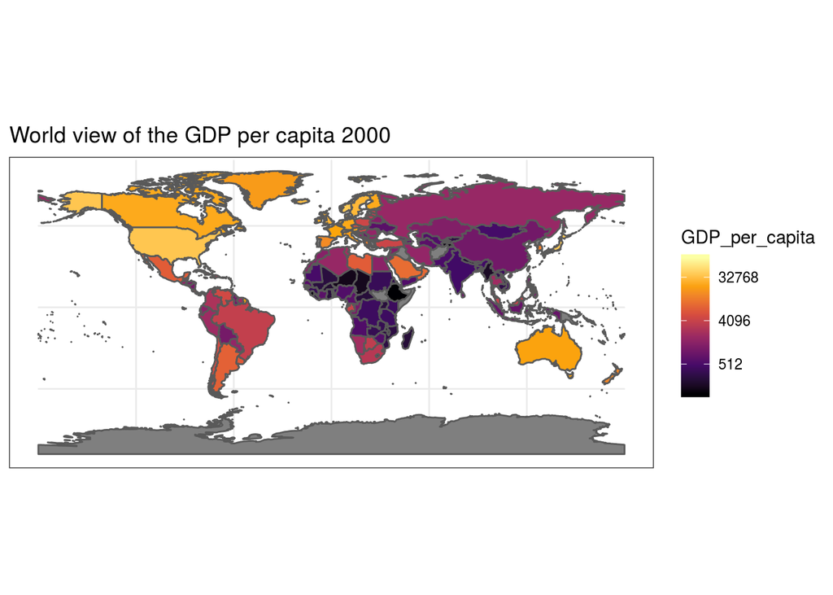

```r
worldplot_by_year(2000)
```

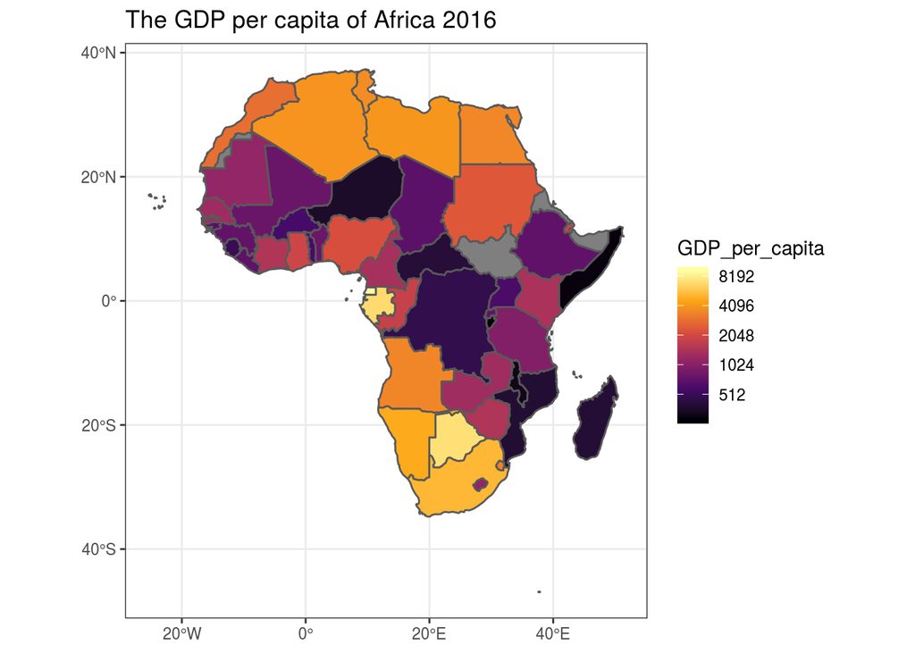

```r
continentplot_by_year("Africa",2016)
```

## Frekari innlestur og úrvinnsla gagna

Til þess að geta borið gögnin saman viljum við frekar skoða verga þróunaraðstoð í stað heildarþróunaraðstoðar fyrir hvert land. Til þess að gera það er ný tafla frá alþjóðabankanum lesin inn sem sýnir fólksfjölda í hverju landi á hverju ári inn í pop töfluna. Henni er síðan umbreytt á það form sem við viljum fá hana með gather fallinu, þar sem dálkarnir verða, Country.Name, Country.Code, Year og Population. Síðan er þessi tafla sameinuð devhelp_by_country_code með Country id-inu og árinu og dálkunum síðan raðað þannig að country id-ið og country name-ið sé fremst. Síðan er búinn til nýr dálkur, devaid_per_capita þar sem hvert gildi samsvarar þróunaraðstoðinni deilt með fólksfjöldanum á hverju ári fyrir hvert land. Sum lönd erum með skilgreinda neikvæða þróunaraðstoð sem þýðir að heildarfjárstreymi þróunarstuðnings er neikvæður, þ.e. að landið hefur á viðkomandi ári greitt til baka af höfuðstóli lána vegna þróunaraðstoðar sem það hefur notið á fyrri árum en það sem nemur stuðningi á árinu. Til einföldunar læt ég þær breytur verða 0 þannig að verga þróunaraðstoðin taki einnig gildið 0 fyrir viðkomandi ár.

```r
pop<-read.csv(file="population/API_SP.POP.TOTL_DS2_en_csv_v2_422125.csv",sep=",",skip=4,header=T)
colnames(pop)<-gsub('X',"",colnames(pop),fixed=TRUE)
pop <- na.omit(pop[ -c(3,4,64:65) ])
pop <- pop %>% gather(Year, Population, -Country.Name, -Country.Code)
newdevaid <- merge(devaid_by_country_code,pop,by.x=c("Country_id","Year"),by.y=c("Country.Code","Year"))
newdevaid <- newdevaid[c(1,4,2,3,5)]
newdevaid[newdevaid < 0] <- 0
newdevaid$devaid_per_capita <- newdevaid$Development_aid / newdevaid$Population
head(newdevaid)
```

```
##   Country_id Country.Name Year Development_aid Population devaid_per_capita
## 1        ABW        Aruba 1985        12040000      63026          191.0323
## 2        ABW        Aruba 1986        40430000      62644          645.3930
## 3        ABW        Aruba 1987        20910000      61833          338.1689
## 4        ABW        Aruba 1988        19290000      61079          315.8205
## 5        ABW        Aruba 1990        29980000      62149          482.3891
## 6        ABW        Aruba 1991        24970000      64622          386.4009
```

## Myndræn framsetning á vergri þróunaraðstoð

Hér er verg þróunaraðstoð sett fram með myndrænum hætti, þar sem að föllin frá myndrænni framsetningu á vergri landsframleiðslu eru nokkurn veginn endurnýtt, sjá má lýsingu á þeim fyrr í skýrslunni. Löndin sem einblínt er á, eru samstarfslönd Íslands í tvíhliða þróunarsamvinnu og svæðasamstarfi.

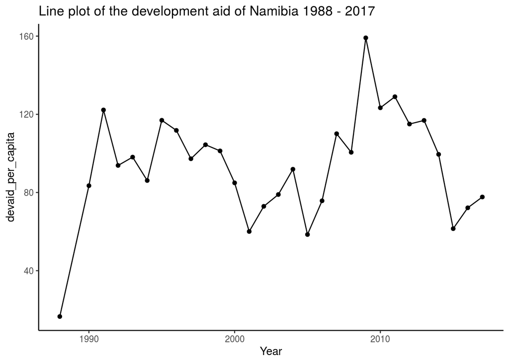

```r
lineplot_country_devaid_by_years<- function(yearFrom,yearTo,country) {
  dat<-newdevaid%>%filter(Country.Name==country & Year>=yearFrom & Year<=yearTo)
  chr = sprintf("Line plot of the development aid of %s %d - %d",country,yearFrom,yearTo)
  ggplot(data = dat, aes(x = Year, y = devaid_per_capita))+geom_point()+geom_line()+ggtitle(chr)+theme(plot.title = element_text(lineheight=.8, face="bold"))+theme_classic()
}

barplot_country_devaid_by_years<- function(yearFrom,yearTo,country) {
  dat<-newdevaid%>%filter(Country.Name==country & Year>=yearFrom & Year<=yearTo)
  chr = sprintf("Bar plot of the development aid of %s %d - %d",country,yearFrom,yearTo)
  ggplot(data = dat, aes(x = Year, y = devaid_per_capita, fill= devaid_per_capita))+geom_bar(stat = "identity")+ggtitle(chr)+theme(plot.title = element_text(lineheight=.8, face="bold"))+theme_classic()
}

lineplot_countries_devaid_by_years<- function(yearFrom,yearTo,conts) {
  dat<-newdevaid%>%filter(Year>=yearFrom & Year<=yearTo & Country.Name %in% conts)
  chr = sprintf("Line plot development aid of selected countries %d - %d",yearFrom,yearTo)
  ggplot(data = dat, aes(x =Year, y = devaid_per_capita, color=Country.Name))+geom_point()+geom_line()+ggtitle(chr)+
  theme(plot.title = element_text(lineheight=.8, face="bold"))+theme_classic()
}

barplot_countries_devaid_by_year<- function(year,conts) {
  dat<-newdevaid%>%filter(year==Year & Country.Name %in% conts)
   chr = sprintf("Bar plot of development help of selected countries in %d",year)
   ggplot(data = dat, aes(x = Country.Name, y = devaid_per_capita, fill=Country.Name))+geom_bar(stat = "identity")+
   theme(plot.title = element_text(lineheight=.8, face="bold"), axis.text.x = element_text(angle = 90, hjust = 1))+ggtitle(chr)+theme_classic()
}
worldplot_devaid_by_year<- function(year) {
  world <- ne_countries(scale = "medium", returnclass = "sf")
  dat<-newdevaid%>%filter(Year == year)
  newdat<-merge(x=world,y=dat,by.x="brk_a3",by.y="Country_id",all.x=TRUE)
  chr = sprintf("World view of development aid %d",year)
  ggplot(newdat, main = chr)+
  geom_sf(data = newdat, aes(fill = devaid_per_capita,)) +
  scale_fill_viridis_c(option = "plasma", trans = "log2")+
  theme(plot.title = element_text(lineheight=.8, face="bold"))+ggtitle(chr)+theme_bw()
}

continentplot_devaid_by_year <- function(cont, year) {
  world <- ne_countries(scale = "medium", returnclass = "sf")
  world <- filter(world,continent == cont)
  dat<-newdevaid%>%filter(Year == year)
  newdat<-merge(x=world,y=dat,by.x="brk_a3",by.y="Country_id",all.x=TRUE)
  chr = sprintf("The development aid per capita of %s %d",cont,year)
  ggplot(newdat, main = chr)+
  geom_sf(data = newdat, aes(fill = devaid_per_capita,)) +
  scale_fill_viridis_c(option = "plasma", trans = "log2")+
  theme(plot.title = element_text(lineheight=.8, face="bold"))+ggtitle(chr)+theme_bw()
}

lineplot_country_devaid_by_years(1988,2017,"Namibia")
```

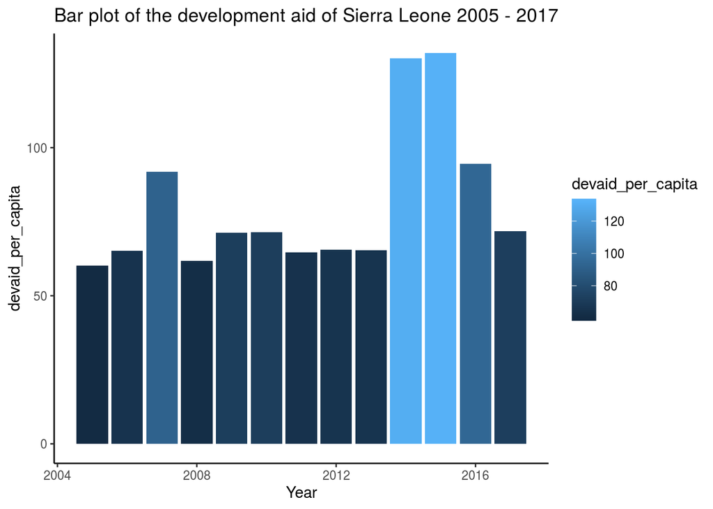

```r
barplot_country_devaid_by_years(2005,2017,"Sierra Leone")
```

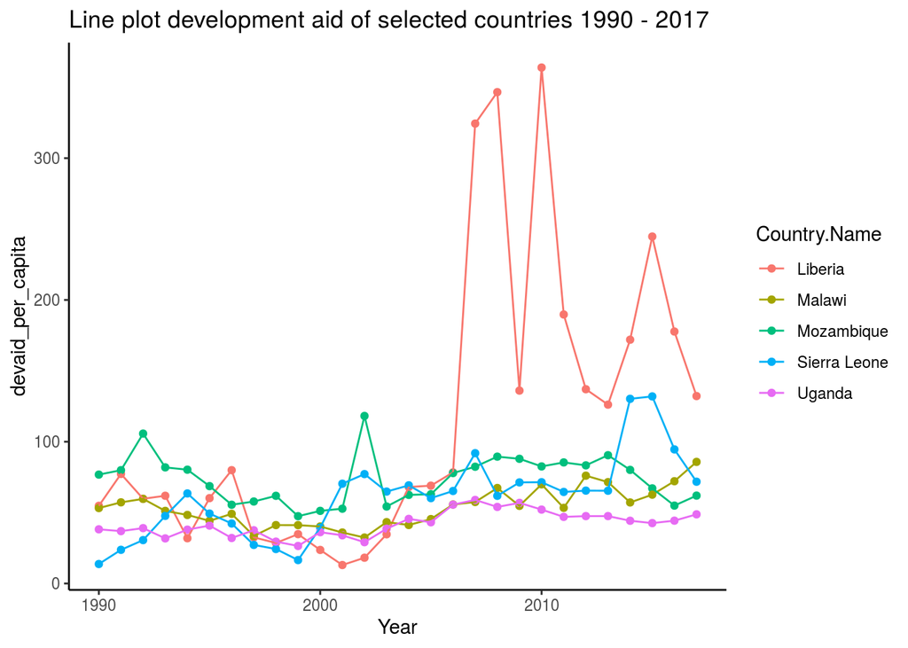

```r
lineplot_countries_devaid_by_years(1990,2017,conts=c("Sierra Leone", "Liberia", "Mozambique","Malawi","Uganda"))
```

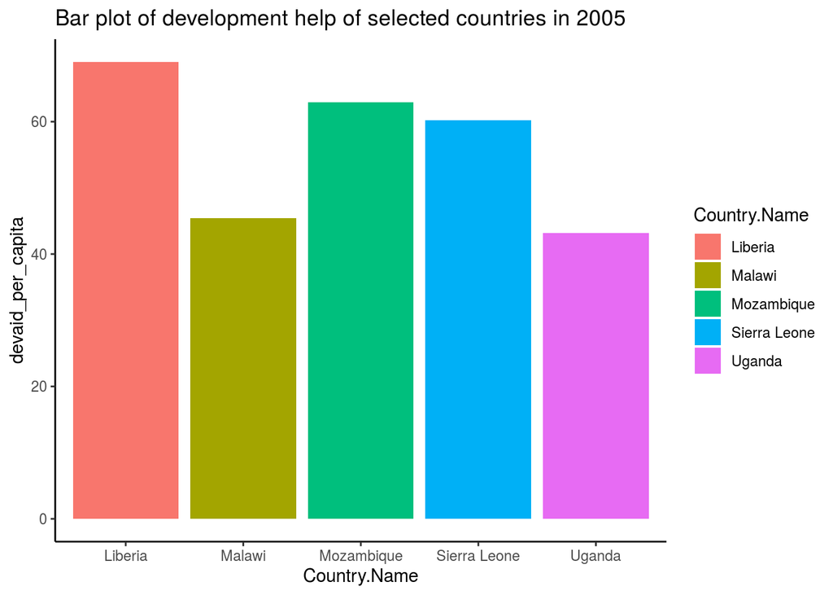

```r
barplot_countries_devaid_by_year(2005,conts=c("Sierra Leone", "Liberia", "Mozambique","Malawi","Uganda"))
```

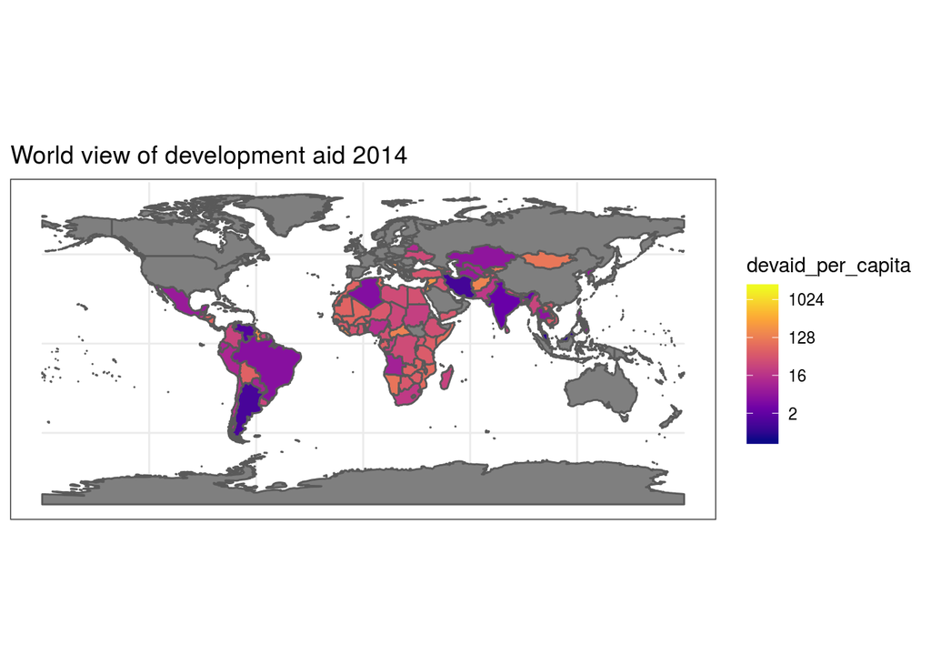

```r
worldplot_devaid_by_year(2014)
```

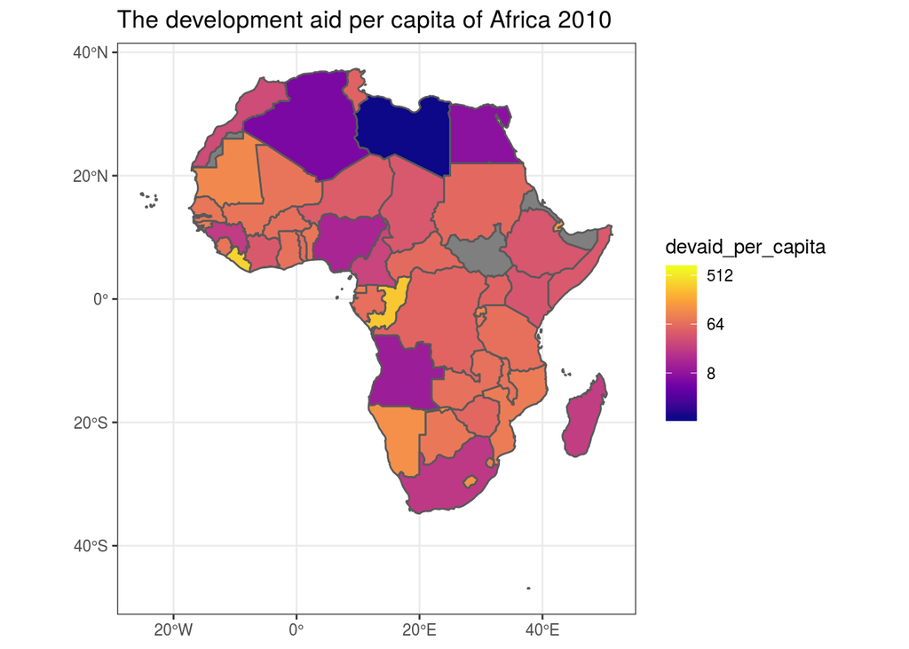

```r
continentplot_devaid_by_year("Africa",2010)
```

## Enn frekari úrvinnsla og gagnahreinsun

Til þess að fá gögnin á endanlegt, þægilegt form, viljum við samaeina töflur enn og aftur, að þessu sinni sameinum við newdevaid og gdp_by_country code og þá erum við komin með allar upplýsingar sem við viljum fá í eina töflu. Enn og aftur er world gagnasettið sótt og þróunaraðstoðar- og landsframleiðslugagnasettin sameinuð í eitt gagnasett, final_table. Síðan er bætt við þá töflu continent og region dálkunum til þess að hægt verði að einskorða gröf við ákveðnar heimsálfur eða hluta heimsálfa með aðstoð world gagnasettsins.

```r
world <- ne_countries(scale = "medium", returnclass = "sf")
final_table<-na.omit(merge(newdevaid,gdp_by_country_code,by = c("Country_id","Year"),all.x=TRUE))
final_table<-final_table%>%filter(Year != 2018)
final_table$continent<-world$continent[match(final_table$Country_id,world$brk_a3)]%>%as.factor()
final_table$region<-world$subregion[match(final_table$Country_id,world$brk_a3)]%>%as.factor()
```

## Gagnagreining og samanburður gagna

Hér verður rýnt í gögnin og ýmsir þættir skoðaðir. Fyrst bý ég til þrjú föll, sem fá inn heimsálfu og sýna þá hvaða lönd eru með hæstu meðal vergu landsframleiðsluna á árabilinu 2000-2018, og hvaða lönd hafa hlotið mestu vergu þróunaraðstoð að meðaltali yfir þetta sama árabil hins vegar. Þetta árabil er valið til þess að fá grófa mynd af því hvernig löndin standa. Síðan er kallað á öll föllin með inntakinu “Africa”, sem er sú heimsáfla sem er áhugaverðust að rýna í þegar að þessum málum kemur. Síðan er skoðað hvaða lönd skora hæst (eða lægst) á þessum sviðum um allan heim með því að búa til nýju töflurnar highest_devaid_overall, highest_gdp_overall og lowest_gdp_overall.

```r
highest_gdp_of_continent <- function(cont) {
  df<-final_table%>%filter(cont == continent & Year>=2000 & Year<=2018)
  df<-df%>%group_by(Country.Name)%>%
  summarise(avg_GDP_per_capita = mean(GDP_per_capita))%>%
  arrange(desc(avg_GDP_per_capita))
  kable(head(df), row.names = FALSE, caption = sprintf("Highest average GDP per capita in %s",cont))%>%kable_styling()
}

lowest_gdp_of_continent <- function(cont) {
  df<-final_table%>%filter(cont == continent & Year>=2000 & Year<=2018)
  df<-df%>%group_by(Country.Name)%>%
  summarise(avg_GDP_per_capita = mean(GDP_per_capita))%>%
  arrange(avg_GDP_per_capita)
  kable(head(df), row.names = FALSE, caption = sprintf("Lowest average GDP per capita in %s",cont))%>%kable_styling()
}

highest_devaid_of_continent <- function(cont) {
  df<-final_table%>%filter(cont == continent & Year>=2000 & Year<=2018)
  df<-df%>%group_by(Country.Name)%>%
  summarise(avg_devaid_per_capita = mean(devaid_per_capita))%>%
  arrange(desc(avg_devaid_per_capita))
  kable(head(df), row.names = FALSE, caption = sprintf("Highest average development aid per capita in %s",cont))%>%kable_styling()
}

highest_devaid_overall <- final_table%>%filter(Year>=2000 & Year<=2018)%>%
  group_by(Country.Name)%>%
  summarise(avg_devaid_per_capita = mean(devaid_per_capita))%>%
  arrange(desc(avg_devaid_per_capita))

highest_gdp_overall <- final_table%>%filter(Year>=2000 & Year<=2018)%>%
  group_by(Country.Name)%>%
  summarise(avg_GDP_per_capita = mean(GDP_per_capita))%>%
  arrange(desc(avg_GDP_per_capita))

lowest_gdp_overall <- final_table%>%filter(Year>=2000 & Year<=2018)%>%
  group_by(Country.Name)%>%
  summarise(avg_GDP_per_capita = mean(GDP_per_capita))%>%
  arrange(avg_GDP_per_capita)


highest_gdp_of_continent("Africa")
```

Highest average GDP per capita in Africa

| Country.Name | avg_GDP_per_capita |
| --- | --- |
| Equatorial Guinea | 12583.649 |
| Libya | 8853.946 |
| Gabon | 7427.670 |
| Botswana | 5894.809 |
| South Africa | 5484.258 |
| Namibia | 4221.435 |

```r
lowest_gdp_of_continent("Africa")
```

Lowest average GDP per capita in Africa

| Country.Name | avg_GDP_per_capita |
| --- | --- |
| Burundi | 204.8115 |
| Somalia | 281.0278 |
| Niger | 305.3116 |
| Congo, Dem. Rep. | 334.1195 |
| Malawi | 338.2613 |
| Ethiopia | 348.6271 |

```r
highest_devaid_of_continent("Africa")
```

Highest average development aid per capita in Africa

| Country.Name | avg_devaid_per_capita |
| --- | --- |
| Cabo Verde | 356.84872 |
| Sao Tome and Principe | 242.73657 |
| Liberia | 147.52431 |
| Djibouti | 144.37136 |
| Namibia | 93.77081 |
| Somalia | 91.76456 |

```r
kable(head(highest_devaid_overall), row.names = FALSE, caption = sprintf("Highest average development aid per capita in the world"))%>%kable_styling()
```

Highest average development aid per capita in the world

| Country.Name | avg_devaid_per_capita |
| --- | --- |
| Nauru | 2626.7202 |
| Tuvalu | 1832.8034 |
| Palau | 1481.9470 |
| Marshall Islands | 1071.3431 |
| Micronesia, Fed. Sts. | 1010.5285 |
| Tonga | 486.4002 |

```r
kable(head(highest_gdp_overall), row.names = FALSE, caption = sprintf("Highest average GDP per capita in the world"))%>%kable_styling()
```

Highest average GDP per capita in the world

| Country.Name | avg_GDP_per_capita |
| --- | --- |
| Post-demographic dividend | 36653.12 |
| High income | 36372.56 |
| OECD members | 33358.81 |
| European Union | 28241.43 |
| Europe & Central Asia | 21037.14 |
| Euro area | 20917.82 |

```r
kable(head(lowest_gdp_overall), row.names = FALSE, caption = sprintf("Lowest average GDP per capita in the world"))%>%kable_styling()
```

Lowest average GDP per capita in the world

| Country.Name | avg_GDP_per_capita |
| --- | --- |
| Burundi | 204.8115 |
| Somalia | 281.0278 |
| Niger | 305.3116 |
| Congo, Dem. Rep. | 334.1195 |
| Malawi | 338.2613 |
| Ethiopia | 348.6271 |

Hér eru föll sem voru búin til fyrr í skýrslunni endurnýtt svo hægt sé að kanna gögin enn frekar.

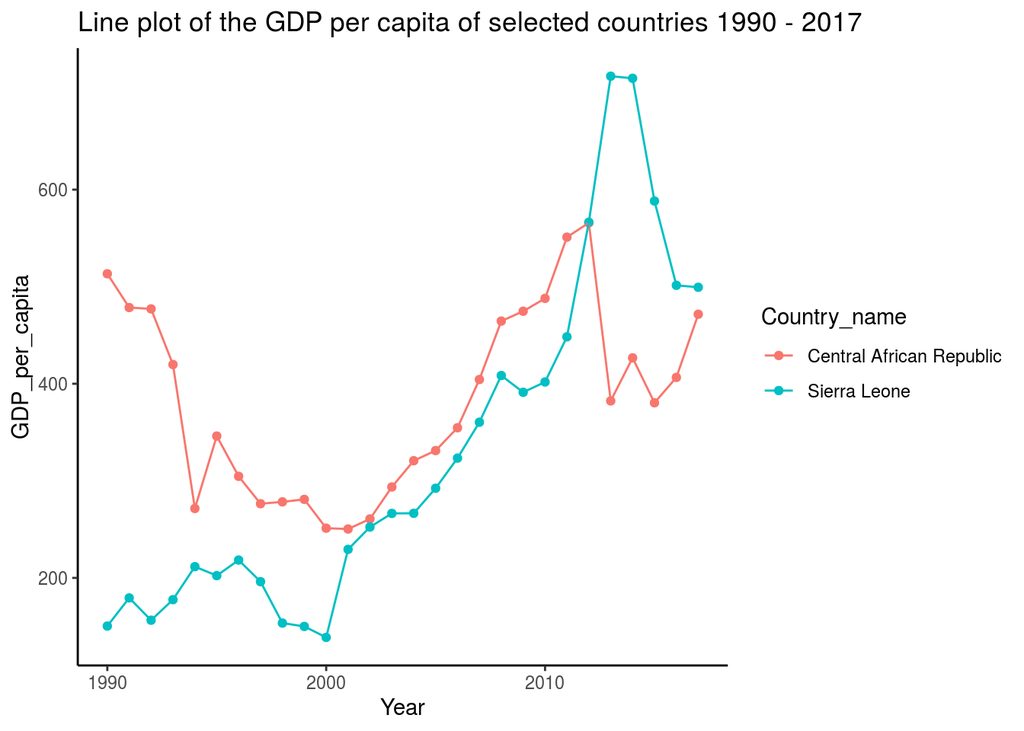

```r
lineplot_countries_gdp_by_years(1990,2017,c("Central African Republic","Sierra Leone"))
```

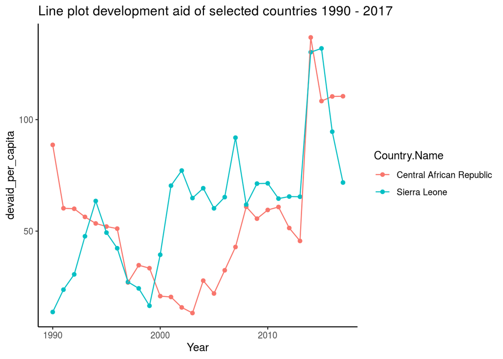

```r
lineplot_countries_devaid_by_years(1990,2017,c("Central African Republic","Sierra Leone"))
```

Hér sjáum við tvö lönd, Sierra Leone og Mið-Afríkulýðveldið sem hafa bæði orðið fyrir mjög miklu efnahagslegu tjóni á einhverju ári á árabilinu 1990-2018, Sierre Leone árið 2014 þegar að ebólufaraldur tröllreið landinu og Mið-Afríkuveldið þegar borgarastyrjöld átti sér stað þar árið 2012. Við sjáum þá önnur lönd bregðast við þessu þar sem að mikil hækkun í vegri þróunaraðstoð á sér stað í báðum löndum árið 2014. Þetta fær mann ef til vill til að íhuga hvort að eitthvað samband sé á milli vergrar þróunaraðstoðar og vergrar landsframleiðslu, en þó bendir niðurstaðan að með Namibíu til annars. Við skulum kanna þetta frekar.

Hér er búið til fallið check_correlation_in_africa sem fær in region og teiknar upp scatter plot þar sem verg landsframleiðslua er sett fram á x-ási og verg þróunaraðstoð sett fram á y-ási á viðkomandi svæði innan Afríku. Síðan er kallað á fallið með svæðum sunnan Sahara sem inntök, suðurhluta Afríku, Vestur-Afríku, Austur-Afríku og Mið-Afríku, en einblínt verður á Afríku sunnan Sahara þar sem mikið af þróunarastoð beinist til landa í þeim heimshluta, og er sérstakt áherslusvæði fyrir íslenska þróunarsamvinnu.

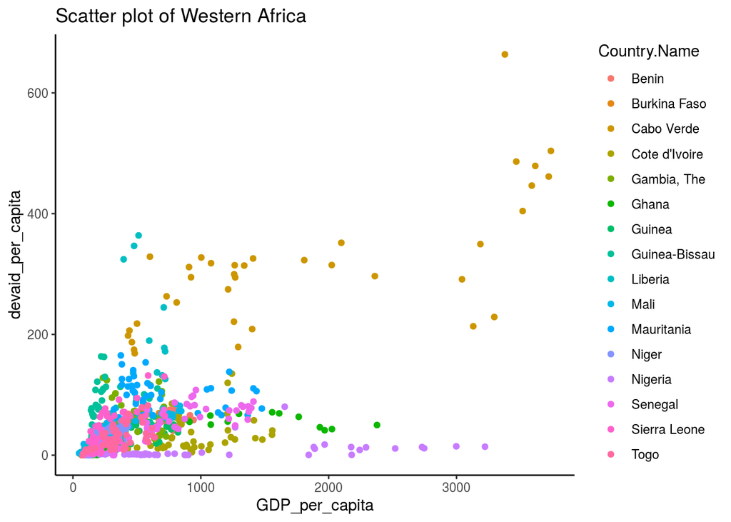

```r
world <- ne_countries(scale = "medium", returnclass = "sf")
merge_dat <- merge(newdevaid,gdp_by_country_code,by=c("Country_id","Year"))
merge_dat <- na.omit(merge_dat)
dat <- merge_dat%>%filter(devaid_per_capita != 0)
merge_dat$continent<-world$continent[match(merge_dat$Country_id,world$brk_a3)]%>%as.factor()
merge_dat$region<-world$subregion[match(merge_dat$Country_id,world$brk_a3)]%>%as.factor()

check_correlation_in_africa <- function (rregion) {
  chr = sprintf("Scatter plot of %s",rregion)
  dat <- merge_dat%>%filter(region == rregion)
  dat$Country.Name = as.factor(dat$Country.Name)
  ggplot(data = dat, aes( x = GDP_per_capita, y = devaid_per_capita, color = Country.Name))+ggtitle(chr) + geom_point()+theme_classic()
}

check_correlation_in_africa("Western Africa")
```

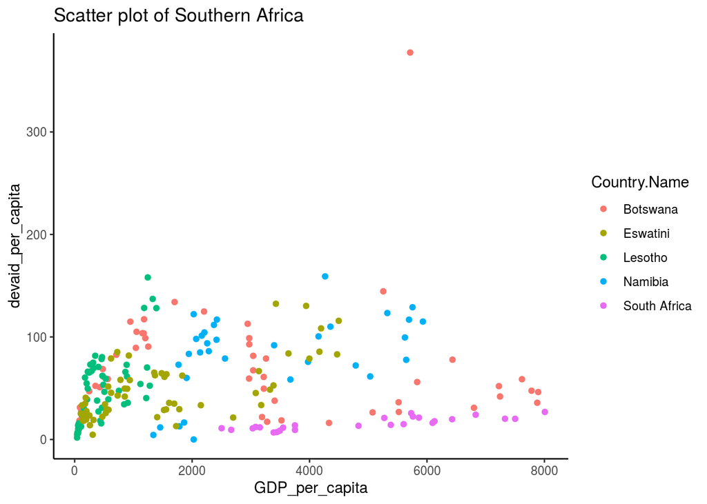

```r
check_correlation_in_africa("Southern Africa")
```

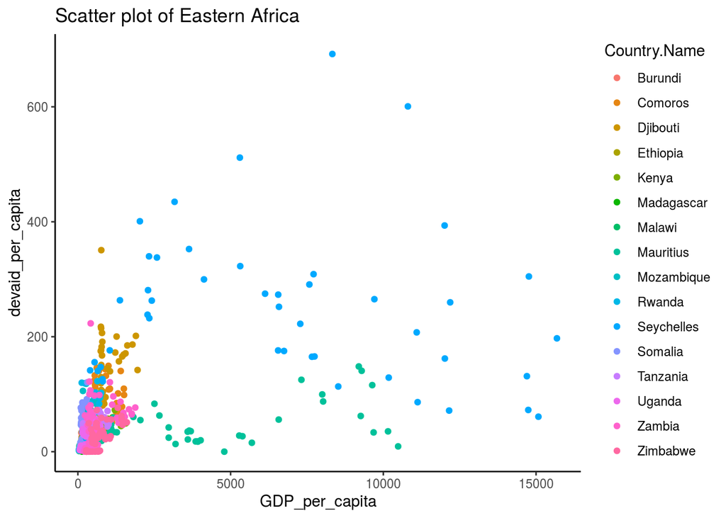

```r
check_correlation_in_africa("Eastern Africa")
```

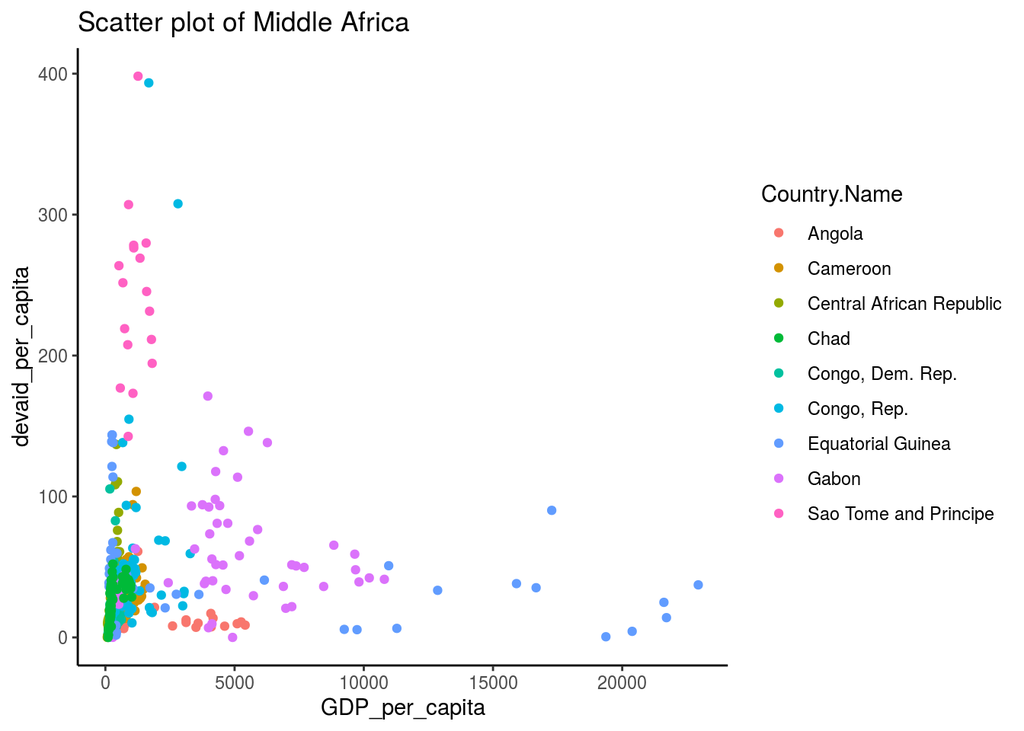

```r
check_correlation_in_africa("Middle Africa")
```

## Niðurstöður

Niðurstöður koma á óvart, þar sem ekki virist vera almenn marktæk fylgni milli vergra þjóðartekna og þróunaraðstoðar. Þess ber að geta að Efnahags- og framfarastofnunin (OECD) hvetur gjafaríki til að færa þróunaraðstoð til þeirra ríkja þar sem fátækt er mest. Ekki er hægt að greina heildrænt mynstur innan svæðanna, en búast hefði mátt við línulegri fylgni með neikvæðri hallatölu. Þó er ljóst að staðan er eilítið mismunandi milli svæða. Þannig njóta lönd í sunnanverðri Afríku minni aðstoðar en lönd annars vegar í álfunni (hér athugist að y-ásinn er á ólíkum kvörðum), enda eru þjóðartekjur hærri á því svæði. Til að kanna betur orsakatengsl, er gagnlegt að rýna í gögn einstakra landa og jafnframt að taka tillit til tímamarka og þess að áhrifin geta verið á báða bóga, umfangsmikil aðstoð á ákveðnu tímabili getur verið áhrifarík og stuðlað að sjálfbærum hagvexti sem kemur fram nokkrum árum síðar. Lekar úr hagkerfi, s.s. nýting náttúruauðlinda af hálfu erlendra ríkja, sem og fjárstreymi úr landi vegna spillingar getur verið af þeim skala að það skaði efnahag og uppbyggingu einstakra landa, eins og dæmin sýna. Einnig getur efnahagsleg velgengni orðið til þess að gjafaríki draga úr þróunaraðstoð sinni til viðkomandi lands. Sem dæmi má nefna að Efnahags- og framfarastofnunin skiptir löndum í tekjuflokka, sem gjafalönd taka tillit til og þegar farið er yfir ákveðna þröskulda í vergum þjóðartekjum, getur slíkt haft veruleg áhrif á stuðning. Sveiflur í stuðningi, s.s. vegna stórra verkefna til innviðauppbyggingar geta einnig þýtt að sveiflur í þróunaraðstoð verða meiri fyrir minni hagkerfi þar sem gögnin miða við íbúafjölda. Þá hafa staðbundin áföll veruleg áhrif, svo sem vopnuð átök og náttúruhamfarir. Slíkir þættir hafa áhrif á gögnin og alhæfingargildi niðurstaðna.